# RRST : Analysis - sample excluding outlier

## 4.2 ) Identifying Covariates for Regression Analysis

We identified SDQ to be correlated with RRST sensitivity and metacognition in the FND population only.

Next, we need to identify which covariates will be included in our linear regression (separate per group) to test whether these correlation survive also the control for these covariates. To do so, we choose those variables that are both theoretically but also statistically correlated with both the predictor (RRST sensitivity and metacognition in our case) and the outcome variable (SDQ in our case).

```r
# does age need to be a covariate in the model ?
cor.test(df_FND$age, df_FND$rrst_sensitivity, method = "pearson")
```

```
    Pearson's product-moment correlation

data:  df_FND$age and df_FND$rrst_sensitivity
t = -0.99609, df = 41, p-value = 0.325
alternative hypothesis: true correlation is not equal to 0
95 percent confidence interval:
 -0.4340205  0.1537269
sample estimates:
      cor
-0.153714
```

```r
cor.test(df_FND$age, df_FND$metascore, method = "pearson")
```

```
    Pearson's product-moment correlation

data:  df_FND$age and df_FND$metascore
t = 1.0698, df = 41, p-value = 0.291
alternative hypothesis: true correlation is not equal to 0
95 percent confidence interval:
 -0.1426087  0.4432013
sample estimates:
      cor
0.1647936
```

```r
cor.test(df_FND$age, df_FND$sdq, method = "pearson")
```

```
    Pearson's product-moment correlation

data:  df_FND$age and df_FND$sdq
t = 1.6267, df = 41, p-value = 0.1115
alternative hypothesis: true correlation is not equal to 0
95 percent confidence interval:
 -0.05844549  0.50892864
sample estimates:
      cor
0.2462205
```

```r
# does bmi need to be a covariate in the model?
cor.test(df_FND$bmi, df_FND$rrst_sensitivity, method = "pearson")
```

```
    Pearson's product-moment correlation

data:  df_FND$bmi and df_FND$rrst_sensitivity
t = -0.5235, df = 41, p-value = 0.6034
alternative hypothesis: true correlation is not equal to 0
95 percent confidence interval:
 -0.3727075  0.2243494
sample estimates:
        cor
-0.08148511
```

```r
cor.test(df_FND$bmi, df_FND$metascore, method = "pearson")
```

```
    Pearson's product-moment correlation

data:  df_FND$bmi and df_FND$metascore
t = -0.58658, df = 41, p-value = 0.5607
alternative hypothesis: true correlation is not equal to 0
95 percent confidence interval:
 -0.3811282  0.2150079
sample estimates:
        cor
-0.09122709
```

```r
cor.test(df_FND$bmi, df_FND$sdq, method = "pearson")
```

```
    Pearson's product-moment correlation

data:  df_FND$bmi and df_FND$sdq
t = -0.97486, df = 41, p-value = 0.3353
alternative hypothesis: true correlation is not equal to 0
95 percent confidence interval:
 -0.4313571  0.1569247
sample estimates:
       cor
-0.1505131
```

```r
# does anx_dep_sum need to be a covariate in the model?
cor.test(df_FND$anx_dep_SUM, df_FND$rrst_sensitivity, method = "pearson")
```

```
    Pearson's product-moment correlation

data:  df_FND$anx_dep_SUM and df_FND$rrst_sensitivity
t = -1.0783, df = 41, p-value = 0.2872
alternative hypothesis: true correlation is not equal to 0
95 percent confidence interval:
 -0.4442492  0.1413301
sample estimates:
       cor
-0.1660627
```

```r
cor.test(df_FND$anx_dep_SUM, df_FND$metascore, method = "pearson")
```

```
    Pearson's product-moment correlation

data:  df_FND$anx_dep_SUM and df_FND$metascore
t = -0.64011, df = 41, p-value = 0.5257
alternative hypothesis: true correlation is not equal to 0
95 percent confidence interval:
 -0.3882177  0.2070577
sample estimates:
       cor
-0.0994722
```

```r
cor.test(df_FND$anx_dep_SUM, df_FND$sdq, method = "pearson") # trend with r= 0.294215, p-value = 0.05548
```

```
    Pearson's product-moment correlation

data:  df_FND$anx_dep_SUM and df_FND$sdq
t = 1.9711, df = 41, p-value = 0.05548
alternative hypothesis: true correlation is not equal to 0
95 percent confidence interval:
 -0.006722943  0.546285935
sample estimates:
     cor
0.294215
```

```r
# does medication need to be a covariate in the model?
res<-t.test(df_FND$rrst_sensitivity[df_FND$psychotropic_medication == "1"], df_FND$rrst_sensitivity[df_FND$psychotropic_medication=="0"])
res # sig difference across groups with or without intake of psychotropic medicatioN: t = -2.1273, p-value = 0.04011
```

```
    Welch Two Sample t-test

data:  df_FND$rrst_sensitivity[df_FND$psychotropic_medication == "1"] and df_FND$rrst_sensitivity[df_FND$psychotropic_medication == "0"]
t = -2.1273, df = 37.077, p-value = 0.04011
alternative hypothesis: true difference in means is not equal to 0
95 percent confidence interval:
 -2.00230723 -0.04882873
sample estimates:
mean of x mean of y
 2.309574  3.335142
```

```r
res<-t.test(df_FND$metascore[df_FND$psychotropic_medication == "1"], df_FND$metascore[df_FND$psychotropic_medication=="0"])
res #
```

```
    Welch Two Sample t-test

data:  df_FND$metascore[df_FND$psychotropic_medication == "1"] and df_FND$metascore[df_FND$psychotropic_medication == "0"]
t = -1.4203, df = 39.126, p-value = 0.1634
alternative hypothesis: true difference in means is not equal to 0
95 percent confidence interval:
 -0.07204124  0.01260121
sample estimates:
mean of x mean of y
0.5533079 0.5830279
```

```r
res<-t.test(df_FND$sdq[df_FND$psychotropic_medication == "1"], df_FND$sdq[df_FND$psychotropic_medication=="0"])
res # sig difference across groups with or without intake of psychotropic medication: t = 2.6337, p-value = 0.0129
```

```
    Welch Two Sample t-test

data:  df_FND$sdq[df_FND$psychotropic_medication == "1"] and df_FND$sdq[df_FND$psychotropic_medication == "0"]
t = 2.6337, df = 32.012, p-value = 0.0129
alternative hypothesis: true difference in means is not equal to 0
95 percent confidence interval:
  2.584876 20.230913
sample estimates:
mean of x mean of y
 46.15789  34.75000
```

```r
# differences of sex in our predictor and outcome variable?
res<-t.test(df_FND$rrst_sensitivity[df_FND$sex=="1"], df_FND$rrst_sensitivity[df_FND$sex=="2"])
res #
```

```
    Welch Two Sample t-test

data:  df_FND$rrst_sensitivity[df_FND$sex == "1"] and df_FND$rrst_sensitivity[df_FND$sex == "2"]
t = -1.1197, df = 15.303, p-value = 0.2801
alternative hypothesis: true difference in means is not equal to 0
95 percent confidence interval:
 -2.0795758  0.6455268
sample estimates:
mean of x mean of y
 2.681884  3.398908
```

```r
res<-t.test(df_FND$metascore[df_FND$sex=="1"], df_FND$metascore[df_FND$sex=="2"])
res #
```

```
    Welch Two Sample t-test

data:  df_FND$metascore[df_FND$sex == "1"] and df_FND$metascore[df_FND$sex == "2"]
t = 1.1436, df = 16.994, p-value = 0.2687
alternative hypothesis: true difference in means is not equal to 0
95 percent confidence interval:
 -0.02470859  0.08319037
sample estimates:
mean of x mean of y
0.5780561 0.5488152
```

```r
res<-t.test(df_FND$sdq[df_FND$sex=="1"], df_FND$sdq[df_FND$sex=="2"])
res #
```

```
    Welch Two Sample t-test

data:  df_FND$sdq[df_FND$sex == "1"] and df_FND$sdq[df_FND$sex == "2"]
t = 0.33612, df = 17.95, p-value = 0.7407
alternative hypothesis: true difference in means is not equal to 0
95 percent confidence interval:
 -9.402255 12.982900
sample estimates:
mean of x mean of y
 40.29032  38.50000
```

Seeing that the intake of psychotropic medication is both correlated to our outcome and predictor variables, we have to include this in our linear regression. We add it in an interaction term with group, as it is correlated with group, and then we run it on the full model (including both groups). For the other variables (sex, age, bmi) we do not have to include those, as they are not statistically correlated to both variables. For affective symptoms - there is a trend, hence we run a supplemantary analysis for including these as well.

## 4.3) Linear Regression

```r
# RRST sensitivity
sdq_lm <- lm(formula = sdq ~  rrst_sensitivity*group + psychotropic_medication,
                 data = df)
summary(sdq_lm)
```

```
Call:
lm(formula = sdq ~ rrst_sensitivity * group + psychotropic_medication,
    data = df)

Residuals:
    Min      1Q  Median      3Q     Max
-23.741  -4.157  -1.555   3.758  38.900

Coefficients:
                         Estimate Std. Error t value Pr(>|t|)
(Intercept)               22.4719     4.8244   4.658 1.18e-05 ***
rrst_sensitivity           0.3626     1.2835   0.282 0.778274
group1                    21.9827     5.8059   3.786 0.000286 ***
psychotropic_medication1   7.2866     2.8532   2.554 0.012460 *
rrst_sensitivity:group1   -3.0980     1.5711  -1.972 0.051916 .
---
Signif. codes:  0 '***' 0.001 '**' 0.01 '*' 0.05 '.' 0.1 ' ' 1

Residual standard error: 9.575 on 84 degrees of freedom
  (2 observations deleted due to missingness)
Multiple R-squared:  0.4898,    Adjusted R-squared:  0.4655
F-statistic: 20.16 on 4 and 84 DF,  p-value: 1.146e-11
```

```r
confint(sdq_lm, level = 0.95)
```

```
                             2.5 %      97.5 %
(Intercept)              12.878160 32.06567055
rrst_sensitivity         -2.189855  2.91497870
group1                   10.436956 33.52837270
psychotropic_medication1  1.612716 12.96052136
rrst_sensitivity:group1  -6.222352  0.02630844
```

```r
  # Save as a text file
  lm_summary <- capture.output(summary(sdq_lm))
  lm_confint <- capture.output(confint(sdq_lm, level = 0.95))
  lm_results <- c("### Linear Model Summary ###", lm_summary,
                "", "### Confidence Intervals ###", lm_confint)
  writeLines(lm_results, "3.3_lm_rrst_med.txt")


sdq_lm_affective <- lm(formula = sdq ~  rrst_sensitivity*group + psychotropic_medication + anx_dep_SUM,
                 data = df)
summary(sdq_lm_affective)  #
```

```
Call:
lm(formula = sdq ~ rrst_sensitivity * group + psychotropic_medication +
    anx_dep_SUM, data = df)

Residuals:
    Min      1Q  Median      3Q     Max
-24.061  -4.445  -1.013   3.018  38.181

Coefficients:
                         Estimate Std. Error t value Pr(>|t|)
(Intercept)              19.57599    5.06195   3.867 0.000218 ***
rrst_sensitivity         -0.03933    1.29067  -0.030 0.975765
group1                   19.12577    5.97891   3.199 0.001954 **
psychotropic_medication1  5.04848    3.11010   1.623 0.108327
anx_dep_SUM               0.10520    0.06154   1.710 0.091094 .
rrst_sensitivity:group1  -2.67953    1.57261  -1.704 0.092146 .
---
Signif. codes:  0 '***' 0.001 '**' 0.01 '*' 0.05 '.' 0.1 ' ' 1

Residual standard error: 9.468 on 83 degrees of freedom
  (2 observations deleted due to missingness)
Multiple R-squared:  0.5071,    Adjusted R-squared:  0.4775
F-statistic: 17.08 on 5 and 83 DF,  p-value: 1.39e-11
```

```r
confint(sdq_lm_affective, level = 0.95)
```

```
                               2.5 %     97.5 %
(Intercept)               9.50798058 29.6440034
rrst_sensitivity         -2.60641766  2.5277619
group1                    7.23395740 31.0175789
psychotropic_medication1 -1.13737894 11.2343361
anx_dep_SUM              -0.01719769  0.2276056
rrst_sensitivity:group1  -5.80738085  0.4483295
```

```r
  # Save as a text file
  lm_summary <- capture.output(summary(sdq_lm_affective))
  lm_confint <- capture.output(confint(sdq_lm_affective, level = 0.95))
  lm_results <- c("### Linear Model Summary ###", lm_summary,
                "", "### Confidence Intervals ###", lm_confint)
  writeLines(lm_results, "3.3_lm_rrst_med_aff.txt")


# metascore
sdq_lm <- lm(formula = sdq ~  metascore*group + psychotropic_medication,
                 data = df)
summary(sdq_lm)  #
```

```
Call:
lm(formula = sdq ~ metascore * group + psychotropic_medication,
    data = df)

Residuals:
    Min      1Q  Median      3Q     Max
-25.427  -3.991  -1.279   3.525  38.022

Coefficients:
                         Estimate Std. Error t value Pr(>|t|)
(Intercept)                18.253     21.722   0.840   0.4031
metascore                   9.522     37.609   0.253   0.8007
group1                     54.342     25.040   2.170   0.0328 *
psychotropic_medication1    7.997      2.760   2.897   0.0048 **
metascore:group1          -73.283     43.279  -1.693   0.0941 .
---
Signif. codes:  0 '***' 0.001 '**' 0.01 '*' 0.05 '.' 0.1 ' ' 1

Residual standard error: 9.56 on 84 degrees of freedom
  (2 observations deleted due to missingness)
Multiple R-squared:  0.4914,    Adjusted R-squared:  0.4672
F-statistic: 20.29 on 4 and 84 DF,  p-value: 1.005e-11
```

```r
confint(sdq_lm, level = 0.95)
```

```
                               2.5 %    97.5 %
(Intercept)               -24.944466  61.44956
metascore                 -65.266950  84.31116
group1                      4.546173 104.13700
psychotropic_medication1    2.508047  13.48622
metascore:group1         -159.348639  12.78268
```

```r
  # Save as a text file
  lm_summary <- capture.output(summary(sdq_lm))
  lm_confint <- capture.output(confint(sdq_lm, level = 0.95))
  lm_results <- c("### Linear Model Summary ###", lm_summary,
                "", "### Confidence Intervals ###", lm_confint)
  writeLines(lm_results, "3.3_lm_meta_med.txt")

sdq_lm_affective <- lm(formula = sdq ~  metascore*group + psychotropic_medication + anx_dep_SUM,
                 data = df)
summary(sdq_lm_affective)  #
```

```
Call:
lm(formula = sdq ~ metascore * group + psychotropic_medication +
    anx_dep_SUM, data = df)

Residuals:
    Min      1Q  Median      3Q     Max
-23.280  -4.199  -1.335   3.362  34.590

Coefficients:
                          Estimate Std. Error t value Pr(>|t|)
(Intercept)               15.41127   21.50568   0.717   0.4756
metascore                  6.75580   37.16375   0.182   0.8562
group1                    51.34935   24.77943   2.072   0.0413 *
psychotropic_medication1   5.78845    2.99396   1.933   0.0566 .
anx_dep_SUM                0.10755    0.06037   1.782   0.0785 .
metascore:group1         -70.57624   42.75691  -1.651   0.1026
---
Signif. codes:  0 '***' 0.001 '**' 0.01 '*' 0.05 '.' 0.1 ' ' 1

Residual standard error: 9.439 on 83 degrees of freedom
  (2 observations deleted due to missingness)
Multiple R-squared:  0.5102,    Adjusted R-squared:  0.4806
F-statistic: 17.29 on 5 and 83 DF,  p-value: 1.088e-11
```

```r
confint(sdq_lm_affective, level = 0.95)
```

```
                                 2.5 %      97.5 %
(Intercept)               -27.36266743  58.1852148
metascore                 -67.16139890  80.6729973
group1                      2.06405554 100.6346377
psychotropic_medication1   -0.16641925  11.7433184
anx_dep_SUM                -0.01252055   0.2276273
metascore:group1         -155.61801619  14.4655269
```

```r
  # Save as a text file
  lm_summary <- capture.output(summary(sdq_lm_affective))
  lm_confint <- capture.output(confint(sdq_lm_affective, level = 0.95))
  lm_results <- c("### Linear Model Summary ###", lm_summary,
                "", "### Confidence Intervals ###", lm_confint)
  writeLines(lm_results, "3.3_lm_meta_med_aff.txt")
```

## 4.4) SUPPLEMENTARY Regression - separate per group and controlling for ANX-DEP sum scores

```r
# RRST sensitivity FND
sdq_lm_FND <- lm(formula = sdq ~  rrst_sensitivity + psychotropic_medication,
                 data = df_FND)
summary(sdq_lm_FND)
```

```
Call:
lm(formula = sdq ~ rrst_sensitivity + psychotropic_medication,
    data = df_FND)

Residuals:
    Min      1Q  Median      3Q     Max
-24.141  -8.096  -2.786   6.417  37.778

Coefficients:
                         Estimate Std. Error t value Pr(>|t|)
(Intercept)                43.391      5.165   8.401 2.28e-10 ***
rrst_sensitivity           -2.591      1.323  -1.959   0.0571 .
psychotropic_medication1    8.751      4.263   2.053   0.0467 *
---
Signif. codes:  0 '***' 0.001 '**' 0.01 '*' 0.05 '.' 0.1 ' ' 1

Residual standard error: 13.16 on 40 degrees of freedom
Multiple R-squared:  0.2279,    Adjusted R-squared:  0.1893
F-statistic: 5.903 on 2 and 40 DF,  p-value: 0.005668
```

```r
confint(sdq_lm_FND, level = 0.95)
```

```
                              2.5 %      97.5 %
(Intercept)              32.9527048 53.82919851
rrst_sensitivity         -5.2640573  0.08229745
psychotropic_medication1  0.1358901 17.36565231
```

```r
sdq_lm_affective_FND <- lm(formula = sdq ~  rrst_sensitivity + psychotropic_medication + anx_dep_SUM,
                 data = df_FND)
summary(sdq_lm_affective_FND)  #
```

```
Call:
lm(formula = sdq ~ rrst_sensitivity + psychotropic_medication +
    anx_dep_SUM, data = df_FND)

Residuals:
    Min      1Q  Median      3Q     Max
-24.312  -8.076  -2.783   5.705  37.430

Coefficients:
                         Estimate Std. Error t value Pr(>|t|)
(Intercept)              39.34986    7.81643   5.034 1.12e-05 ***
rrst_sensitivity         -2.60166    1.33144  -1.954   0.0579 .
psychotropic_medication1  6.88075    5.06997   1.357   0.1825
anx_dep_SUM               0.07699    0.11120   0.692   0.4928
---
Signif. codes:  0 '***' 0.001 '**' 0.01 '*' 0.05 '.' 0.1 ' ' 1

Residual standard error: 13.25 on 39 degrees of freedom
Multiple R-squared:  0.2373,    Adjusted R-squared:  0.1786
F-statistic: 4.044 on 3 and 39 DF,  p-value: 0.0135
```

```r
confint(sdq_lm_affective_FND, level = 0.95)
```

```
                              2.5 %      97.5 %
(Intercept)              23.5396403 55.16007691
rrst_sensitivity         -5.2947400  0.09142542
psychotropic_medication1 -3.3742320 17.13572965
anx_dep_SUM              -0.1479358  0.30190731
```

```r
# RRST sensitivity HC
sdq_lm_HC <- lm(formula = sdq ~  rrst_sensitivity + psychotropic_medication,
                 data = df_HC)
summary(sdq_lm_HC)
```

```
Call:
lm(formula = sdq ~ rrst_sensitivity + psychotropic_medication,
    data = df_HC)

Residuals:
   Min     1Q Median     3Q    Max
-4.328 -3.163 -1.072  1.924 11.822

Coefficients:
                         Estimate Std. Error t value Pr(>|t|)
(Intercept)              24.45286    2.05771  11.884 3.57e-15 ***
rrst_sensitivity         -0.09285    0.54018  -0.172    0.864
psychotropic_medication1 -0.76881    2.93689  -0.262    0.795
---
Signif. codes:  0 '***' 0.001 '**' 0.01 '*' 0.05 '.' 0.1 ' ' 1

Residual standard error: 3.865 on 43 degrees of freedom
  (2 observations deleted due to missingness)
Multiple R-squared:  0.001805,  Adjusted R-squared:  -0.04462
F-statistic: 0.03888 on 2 and 43 DF,  p-value: 0.9619
```

```r
confint(sdq_lm_HC, level = 0.95)
```

```
                             2.5 %     97.5 %
(Intercept)              20.303100 28.6026252
rrst_sensitivity         -1.182222  0.9965168
psychotropic_medication1 -6.691613  5.1539933
```

```r
sdq_lm_affective_HC <- lm(formula = sdq ~  rrst_sensitivity + psychotropic_medication + anx_dep_SUM,
                 data = df_HC)
summary(sdq_lm_affective_HC)  #
```

```
Call:
lm(formula = sdq ~ rrst_sensitivity + psychotropic_medication +
    anx_dep_SUM, data = df_HC)

Residuals:
    Min      1Q  Median      3Q     Max
-6.1591 -2.8961 -0.4383  1.9792  8.4374

Coefficients:
                         Estimate Std. Error t value Pr(>|t|)
(Intercept)              20.46811    2.17139   9.426 6.35e-12 ***
rrst_sensitivity         -0.45618    0.49392  -0.924   0.3610
psychotropic_medication1 -1.35880    2.62913  -0.517   0.6080
anx_dep_SUM               0.12607    0.03657   3.447   0.0013 **
---
Signif. codes:  0 '***' 0.001 '**' 0.01 '*' 0.05 '.' 0.1 ' ' 1

Residual standard error: 3.453 on 42 degrees of freedom
  (2 observations deleted due to missingness)
Multiple R-squared:  0.222, Adjusted R-squared:  0.1664
F-statistic: 3.994 on 3 and 42 DF,  p-value: 0.0137
```

```r
confint(sdq_lm_affective_HC, level = 0.95)
```

```
                               2.5 %     97.5 %
(Intercept)              16.08607859 24.8501447
rrst_sensitivity         -1.45294757  0.5405941
psychotropic_medication1 -6.66459477  3.9470002
anx_dep_SUM               0.05226925  0.1998698
```

```r
# metascore FND
sdq_lm_FND <- lm(formula = sdq ~  metascore + psychotropic_medication,
                 data = df_FND)
summary(sdq_lm_FND)  #
```

```
Call:
lm(formula = sdq ~ metascore + psychotropic_medication, data = df_FND)

Residuals:
    Min      1Q  Median      3Q     Max
-25.720  -7.438  -3.396   8.541  37.124

Coefficients:
                         Estimate Std. Error t value Pr(>|t|)
(Intercept)                70.469     17.675   3.987 0.000277 ***
metascore                 -61.264     29.966  -2.044 0.047528 *
psychotropic_medication1    9.587      4.123   2.326 0.025200 *
---
Signif. codes:  0 '***' 0.001 '**' 0.01 '*' 0.05 '.' 0.1 ' ' 1

Residual standard error: 13.11 on 40 degrees of freedom
Multiple R-squared:  0.2339,    Adjusted R-squared:  0.1956
F-statistic: 6.106 on 2 and 40 DF,  p-value: 0.004851
```

```r
confint(sdq_lm_FND, level = 0.95)
```

```
                               2.5 %     97.5 %
(Intercept)                34.747037 106.190457
metascore                -121.827371  -0.701054
psychotropic_medication1    1.255103  17.919140
```

```r
sdq_lm_affective_FND <- lm(formula = sdq ~  metascore + psychotropic_medication + anx_dep_SUM,
                 data = df_FND)
summary(sdq_lm_affective_FND)  #
```

```
Call:
lm(formula = sdq ~ metascore + psychotropic_medication + anx_dep_SUM,
    data = df_FND)

Residuals:
    Min      1Q  Median      3Q     Max
-24.069  -7.355  -2.813   7.833  34.746

Coefficients:
                          Estimate Std. Error t value Pr(>|t|)
(Intercept)               66.54227   18.59586   3.578 0.000944 ***
metascore                -61.78579   30.15574  -2.049 0.047244 *
psychotropic_medication1   7.64265    4.94639   1.545 0.130400
anx_dep_SUM                0.07988    0.11073   0.721 0.474958
---
Signif. codes:  0 '***' 0.001 '**' 0.01 '*' 0.05 '.' 0.1 ' ' 1

Residual standard error: 13.19 on 39 degrees of freedom
Multiple R-squared:  0.244, Adjusted R-squared:  0.1858
F-statistic: 4.195 on 3 and 39 DF,  p-value: 0.0115
```

```r
confint(sdq_lm_affective_FND, level = 0.95)
```

```
                                2.5 %      97.5 %
(Intercept)                28.9286047 104.1559436
metascore                -122.7815257  -0.7900468
psychotropic_medication1   -2.3623702  17.6476663
anx_dep_SUM                -0.1440951   0.3038646
```

```r
# metascore HC

sdq_lm_HC <- lm(formula = sdq ~  metascore + psychotropic_medication,
                 data = df_HC)
summary(sdq_lm_HC)  #
```

```
Call:
lm(formula = sdq ~ metascore + psychotropic_medication, data = df_HC)

Residuals:
   Min     1Q Median     3Q    Max
-4.280 -3.087 -1.230  2.018 11.924

Coefficients:
                         Estimate Std. Error t value Pr(>|t|)
(Intercept)               21.7955     8.8443   2.464   0.0178 *
metascore                  4.0164    15.2906   0.263   0.7941
psychotropic_medication1  -0.5258     2.8134  -0.187   0.8526
---
Signif. codes:  0 '***' 0.001 '**' 0.01 '*' 0.05 '.' 0.1 ' ' 1

Residual standard error: 3.864 on 43 degrees of freedom
  (2 observations deleted due to missingness)
Multiple R-squared:  0.002719,  Adjusted R-squared:  -0.04367
F-statistic: 0.05863 on 2 and 43 DF,  p-value: 0.9431
```

```r
confint(sdq_lm_HC, level = 0.95)
```

```
                              2.5 %    97.5 %
(Intercept)                3.959307 39.631774
metascore                -26.820060 34.852853
psychotropic_medication1  -6.199508  5.147904
```

```r
sdq_lm_affective_HC <- lm(formula = sdq ~  metascore + psychotropic_medication + anx_dep_SUM,
                 data = df_HC)
summary(sdq_lm_affective_HC)  #
```

```
Call:
lm(formula = sdq ~ metascore + psychotropic_medication + anx_dep_SUM,
    data = df_HC)

Residuals:
   Min     1Q Median     3Q    Max
-5.935 -2.825 -0.655  2.306  8.960

Coefficients:
                         Estimate Std. Error t value Pr(>|t|)
(Intercept)              17.65519    8.07978   2.185  0.03451 *
metascore                 2.52815   13.80551   0.183  0.85558
psychotropic_medication1 -0.54217    2.53876  -0.214  0.83193
anx_dep_SUM               0.11865    0.03609   3.287  0.00205 **
---
Signif. codes:  0 '***' 0.001 '**' 0.01 '*' 0.05 '.' 0.1 ' ' 1

Residual standard error: 3.487 on 42 degrees of freedom
  (2 observations deleted due to missingness)
Multiple R-squared:  0.2068,    Adjusted R-squared:  0.1501
F-statistic:  3.65 on 3 and 42 DF,  p-value: 0.01995
```

```r
confint(sdq_lm_affective_HC, level = 0.95)
```

```
                               2.5 %     97.5 %
(Intercept)                1.3495342 33.9608409
metascore                -25.3324965 30.3887882
psychotropic_medication1  -5.6655976  4.5812588
anx_dep_SUM                0.0458067  0.1914852
```

# 5) Modeling Accuracy Interaction (R-script from Reviewer 3)

```r
library(tidyverse)
library(glmmTMB)
library(ggeffects)
library(patchwork)
library(sjPlot)
library(ggplot2)
library(ggthemes)

# Example RRST analysis script: modeling confidence data
# Assumes 'rrst_data' contains:
# - confidence: trial-level confidence ratings (scaled 0-1)
# - stimLevel: stimulus intensity (continuous or ordinal)
# - ResponseAccuracy: binary (0 = incorrect, 1 = correct)
# - group: factor (e.g., "FND", "Control")
# - SDQ_score: continuous clinical variable (e.g., dissociation)
# - pcode: participant ID

rrst_confidence_analysis <- readxl::read_xlsx( "/Users/nataschastoffel/Documents/GitHub/RRST_FND/markdown/data/rrst_confidence_analysis.xlsx", na = c("NaN", "NA", ""))
# data is in wide format, so we have to change to long

library(tidyverse)

rrst_data <- rrst_confidence_analysis %>%
  pivot_longer(
    cols = matches("^(accuracy|stim|conf)_trial\\d+$"),
    names_to = c(".value", "trial"),
    names_pattern = "(accuracy|stim|conf)_trial(\\d+)"
  ) %>%
  rename(
    ResponseAccuracy = accuracy,
    stimLevel = stim,
    confidence = conf
  ) %>%
  mutate(
    trial = as.integer(trial),
    ResponseAccuracy = as.integer(ResponseAccuracy),  # binary
    stimLevel = as.numeric(stimLevel),                # continuous
    confidence = as.numeric(confidence),              # continuous
    group = as.factor(group),
    sdq = as.numeric(sdq),
    pcode = as.character(pcode) )


# Note: Consider including (1 | stimLevel) as a random effect to control for stimulus-level variance if needed

rrst_data <- rrst_data %>%
  mutate(
    ResponseAccuracy = factor(ResponseAccuracy, levels = c(1, 0), labels = c("Correct", "Incorrect")),
    group = factor(group),  # Make sure group is also a factor if needed
    pcode = as.character(pcode)
  )

# Model: Confidence ~ Stimulus × Accuracy × Group + (1|pcode)
conf_fit <- glmmTMB(confidence ~ stimLevel * ResponseAccuracy * group + (1 | pcode) + (1 | stimLevel),
                   data = rrst_data,
                   family = ordbeta(),
                   start = list(psi = c(0, 1)))

summary(conf_fit)
```

```
 Family: ordbeta  ( logit )
Formula:
confidence ~ stimLevel * ResponseAccuracy * group + (1 | pcode) +
    (1 | stimLevel)
Data: rrst_data

      AIC       BIC    logLik -2*log(L)  df.resid
   3970.6    4053.9   -1972.3    3944.6      4470

Random effects:

Conditional model:
 Groups    Name        Variance Std.Dev.
 pcode     (Intercept) 0.37135  0.6094
 stimLevel (Intercept) 0.04017  0.2004
Number of obs: 4483, groups:  pcode, 91; stimLevel, 17

Dispersion parameter for ordbeta family (): 3.19

Conditional model:
                                            Estimate Std. Error z value
(Intercept)                                  0.22137    0.29777   0.743
stimLevel                                    0.03737    0.02184   1.711
ResponseAccuracyIncorrect                    0.10508    0.28360   0.370
groupHC                                     -0.42289    0.30412  -1.391
stimLevel:ResponseAccuracyIncorrect         -0.04768    0.02088  -2.283
stimLevel:groupHC                            0.03203    0.02027   1.580
ResponseAccuracyIncorrect:groupHC            0.26384    0.36591   0.721
stimLevel:ResponseAccuracyIncorrect:groupHC -0.01864    0.02769  -0.673
                                            Pr(>|z|)
(Intercept)                                   0.4572
stimLevel                                     0.0871 .
ResponseAccuracyIncorrect                     0.7110
groupHC                                       0.1644
stimLevel:ResponseAccuracyIncorrect           0.0224 *
stimLevel:groupHC                             0.1141
ResponseAccuracyIncorrect:groupHC             0.4709
stimLevel:ResponseAccuracyIncorrect:groupHC   0.5008
---
Signif. codes:  0 '***' 0.001 '**' 0.01 '*' 0.05 '.' 0.1 ' ' 1
```

```r
# Model summary table
tab_model(conf_fit,
         pred.labels = c("Intercept",
                         "Stimulus Intensity",
                         "Response Accuracy",
                         "Group (FND vs Control)",
                         "Stim × Accuracy",
                         "Stim × Group",
                         "Accuracy × Group",
                         "Stim × Accuracy × Group"),
         dv.labels = "Confidence",
         file = "RRST_confidence_model.doc")
```

|  | Confidence |  |  |
| --- | --- | --- | --- |
| Predictors | Estimates | CI | p |
| Intercept | 1.25 | 0.70 – 2.24 | 0.457 |
| Stimulus Intensity | 1.04 | 0.99 – 1.08 | 0.087 |
| Response Accuracy | 1.11 | 0.64 – 1.94 | 0.711 |
| Group (FND vs Control) | 0.66 | 0.36 – 1.19 | 0.164 |
| Stim × Accuracy | 0.95 | 0.92 – 0.99 | **0.022** |
| Stim × Group | 1.03 | 0.99 – 1.07 | 0.114 |
| Accuracy × Group | 1.30 | 0.64 – 2.67 | 0.471 |
| Stim × Accuracy × Group | 0.98 | 0.93 – 1.04 | 0.501 |
| Random Effects |  |  |  |
| σ<sup>2</sup> | 0.14 |  |  |
| τ<sub>00</sub> <sub>pcode</sub> | 0.37 |  |  |
| τ<sub>00</sub> <sub>stimLevel</sub> | 0.04 |  |  |
| ICC | 0.75 |  |  |
| N <sub>pcode</sub> | 91 |  |  |
| N <sub>stimLevel</sub> | 17 |  |  |
| Observations | 4483 |  |  |
| Marginal R<sup>2</sup> / Conditional R<sup>2</sup> | 0.106 / 0.775 |  |  |

```r
# Define palette
color_palette <- c("Correct" = "#1b9e77", "Incorrect" = "#d95f02")

# Plot 1: Group × Accuracy Interaction
plot_group_accuracy <- plot_model(conf_fit, type = "pred", terms = c("group", "ResponseAccuracy")) +
 scale_color_manual(values = color_palette) +
 labs(title = "Group and Accuracy Interaction",
      x = "Group",
      y = "Predicted Confidence") +
 theme_minimal(base_size = 14) +
 theme(legend.position = "top",
       plot.title = element_text(face = "bold", hjust = 0.5),
       axis.title = element_text(size = 16),
       axis.text = element_text(size = 14))
```

```
You are calculating adjusted predictions on the population-level (i.e.
  `type = "fixed"`) for a *generalized* linear mixed model.
  This may produce biased estimates due to Jensen's inequality. Consider
  setting `bias_correction = TRUE` to correct for this bias.
  See also the documentation of the `bias_correction` argument.
```

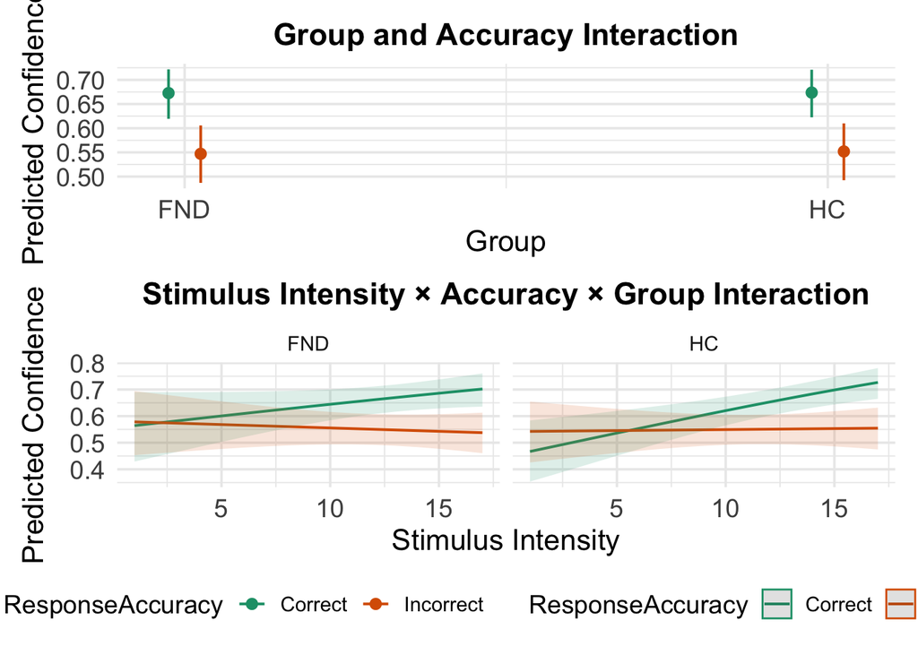

```r
# Plot 2: Stimulus × Accuracy × Group Interaction
plot_stim_acc_group <- plot_model(conf_fit, type = "pred", terms = c("stimLevel", "ResponseAccuracy", "group")) +
  scale_color_manual(values = color_palette) +
  scale_fill_manual(values = color_palette) +
  labs(title = "Stimulus Intensity × Accuracy × Group Interaction",
       x = "Stimulus Intensity",
       y = "Predicted Confidence") +
  theme_minimal(base_size = 14) +
  theme(legend.position = "top",
        plot.title = element_text(face = "bold", hjust = 0.5),
        axis.title = element_text(size = 16),
        axis.text = element_text(size = 14))
# Combine plots
combined_plot <- plot_group_accuracy / plot_stim_acc_group +
 plot_layout(guides = 'collect') & theme(legend.position = "bottom")

print(combined_plot)
```

```r
ggsave("5_Accuracy_interactions_GROUP.tiff",
       plot = combined_plot,
       dpi = 600,
       width = 6,
       height = 4,
       units = "in",
       device = "tiff",
       compression = "lzw")
```

## 5.2) Interaction with SDQ

```r
# Model: Confidence ~ Stimulus × Accuracy × Group + (1|pcode)
conf_fit <- glmmTMB(confidence ~ stimLevel * ResponseAccuracy * sdq + (1 | pcode) + (1 | stimLevel),
                   data = rrst_data,
                   family = ordbeta(),
                   start = list(psi = c(0, 1)))
summary(conf_fit)
```

```
 Family: ordbeta  ( logit )
Formula:
confidence ~ stimLevel * ResponseAccuracy * sdq + (1 | pcode) +
    (1 | stimLevel)
Data: rrst_data

      AIC       BIC    logLik -2*log(L)  df.resid
   3930.6    4013.9   -1952.3    3904.6      4470

Random effects:

Conditional model:
 Groups    Name        Variance Std.Dev.
 pcode     (Intercept) 0.36705  0.6058
 stimLevel (Intercept) 0.04832  0.2198
Number of obs: 4483, groups:  pcode, 91; stimLevel, 17

Dispersion parameter for ordbeta family (): 3.22

Conditional model:
                                          Estimate Std. Error z value Pr(>|z|)
(Intercept)                             -1.0526862  0.4103804  -2.565  0.01031
stimLevel                                0.1552625  0.0288582   5.380 7.44e-08
ResponseAccuracyIncorrect                1.1060807  0.4739671   2.334  0.01961
sdq                                      0.0331362  0.0115360   2.872  0.00407
stimLevel:ResponseAccuracyIncorrect     -0.1499379  0.0369706  -4.056 5.00e-05
stimLevel:sdq                           -0.0031433  0.0007546  -4.165 3.11e-05
ResponseAccuracyIncorrect:sdq           -0.0232996  0.0142408  -1.636  0.10181
stimLevel:ResponseAccuracyIncorrect:sdq  0.0025795  0.0010877   2.372  0.01772

(Intercept)                             *
stimLevel                               ***
ResponseAccuracyIncorrect               *
sdq                                     **
stimLevel:ResponseAccuracyIncorrect     ***
stimLevel:sdq                           ***
ResponseAccuracyIncorrect:sdq
stimLevel:ResponseAccuracyIncorrect:sdq *
---
Signif. codes:  0 '***' 0.001 '**' 0.01 '*' 0.05 '.' 0.1 ' ' 1
```

```r
# Model summary table
tab_model(conf_fit,
         pred.labels = c("Intercept",
                         "Stimulus Intensity",
                         "Response Accuracy",
                         "SDQ",
                         "Stim × Accuracy",
                         "Stim × SDQ",
                         "Accuracy × SDQ",
                         "Stim × Accuracy × SDQ"),
         dv.labels = "Confidence",
         file = "RRST_confidence_model.doc")
```

|  | Confidence |  |  |
| --- | --- | --- | --- |
| Predictors | Estimates | CI | p |
| Intercept | 0.35 | 0.16 – 0.78 | **0.010** |
| Stimulus Intensity | 1.17 | 1.10 – 1.24 | **<0.001** |
| Response Accuracy | 3.02 | 1.19 – 7.65 | **0.020** |
| SDQ | 1.03 | 1.01 – 1.06 | **0.004** |
| Stim × Accuracy | 0.86 | 0.80 – 0.93 | **<0.001** |
| Stim × SDQ | 1.00 | 1.00 – 1.00 | **<0.001** |
| Accuracy × SDQ | 0.98 | 0.95 – 1.00 | 0.102 |
| Stim × Accuracy × SDQ | 1.00 | 1.00 – 1.00 | **0.018** |
| Random Effects |  |  |  |
| σ<sup>2</sup> | 0.14 |  |  |
| τ<sub>00</sub> <sub>pcode</sub> | 0.37 |  |  |
| τ<sub>00</sub> <sub>stimLevel</sub> | 0.05 |  |  |
| ICC | 0.75 |  |  |
| N <sub>pcode</sub> | 91 |  |  |
| N <sub>stimLevel</sub> | 17 |  |  |
| Observations | 4483 |  |  |
| Marginal R<sup>2</sup> / Conditional R<sup>2</sup> | 0.129 / 0.784 |  |  |

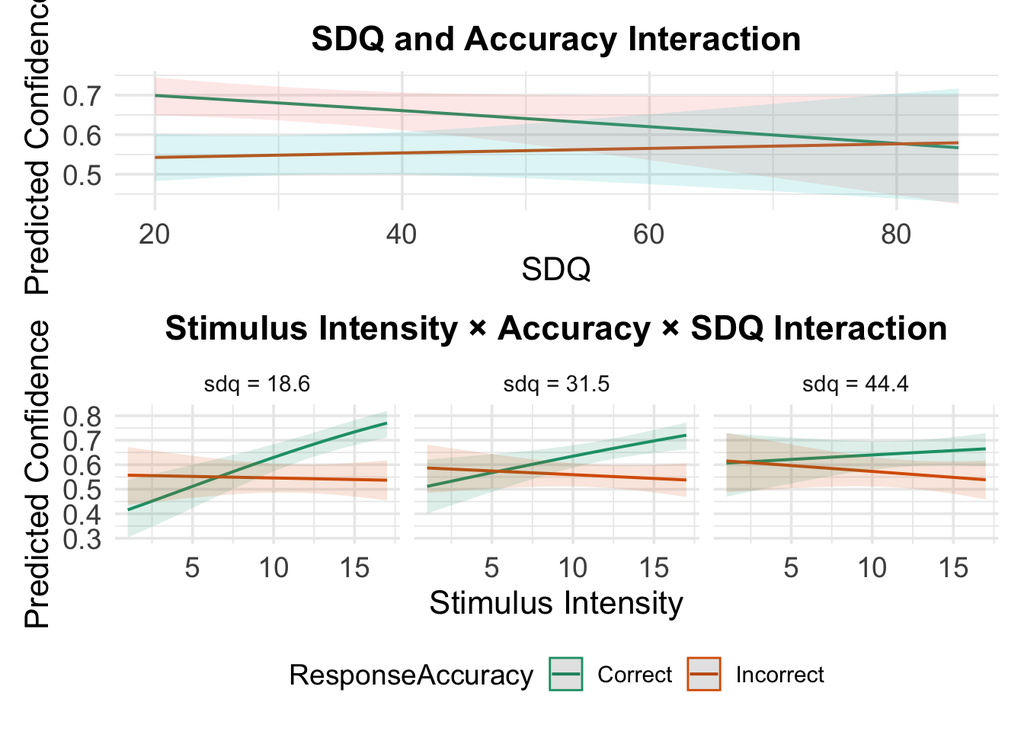

```r
# Define palette
color_palette <- c("Correct" = "#1b9e77", "Incorrect" = "#d95f02")

# Plot 1: SDQ × Accuracy Interaction
plot_sdq_accuracy <- plot_model(conf_fit, type = "pred", terms = c("sdq", "ResponseAccuracy")) +
 scale_color_manual(values = color_palette) +
 labs(title = "SDQ and Accuracy Interaction",
      x = "SDQ",
      y = "Predicted Confidence") +
 theme_minimal(base_size = 14) +
 theme(legend.position = "top",
       plot.title = element_text(face = "bold", hjust = 0.5),
       axis.title = element_text(size = 16),
       axis.text = element_text(size = 14))
# Plot 2: Stimulus × Accuracy × SDQ Interaction
plot_stim_acc_sdq <- plot_model(conf_fit, type = "pred", terms = c("stimLevel", "ResponseAccuracy", "sdq")) +
  scale_color_manual(values = color_palette) +
  scale_fill_manual(values = color_palette) +
  labs(title = "Stimulus Intensity × Accuracy × SDQ Interaction",
       x = "Stimulus Intensity",
       y = "Predicted Confidence") +
  theme_minimal(base_size = 14) +
  theme(legend.position = "top",
        plot.title = element_text(face = "bold", hjust = 0.5),
        axis.title = element_text(size = 16),
        axis.text = element_text(size = 14))
# Combine plots
combined_plot <- plot_sdq_accuracy / plot_stim_acc_sdq +
 plot_layout(guides = 'collect') & theme(legend.position = "bottom")

print(combined_plot)
```

```r
ggsave("5_Accuracy_interactions_SDQ.tiff",
       plot = combined_plot,
       dpi = 600,
       width = 6,
       height = 4,
       units = "in",
       device = "tiff",
       compression = "lzw")
```